# Finding the urban extent in China

George WIllis

2023-01-07

## Aims

Find the urban extent of cities in China using multi-source data. This combines Nightime light data (NTL) with Point of interest (POI) data to provide the urban extent of Beijing.

## Methods

For this we use ArcPy package and ArcMap to plot. We use the NTL data from 2018 and the POI from 2018 in order to get the urban area within China at this time. The first step is to calculate POI density and generate a POI density map with kernel density functions with the spatial resolution of 500 m. We use a bandwidth of 3000m. In this study, ‘geometric mean’ is used to integrate night-time light data and POI data as they have considerable differences in values at the pixel level. This method effectively fuses this data together in order to create a non biased single value at each pixel, unimpaired by any possible outliers.

We then create an urban area from this fused dataset from 2018. Using a density curve analysis we identify the inflection point between the rural and built-up area is 500. An example of the urban area for Beijing regions is shown in the Figure below.

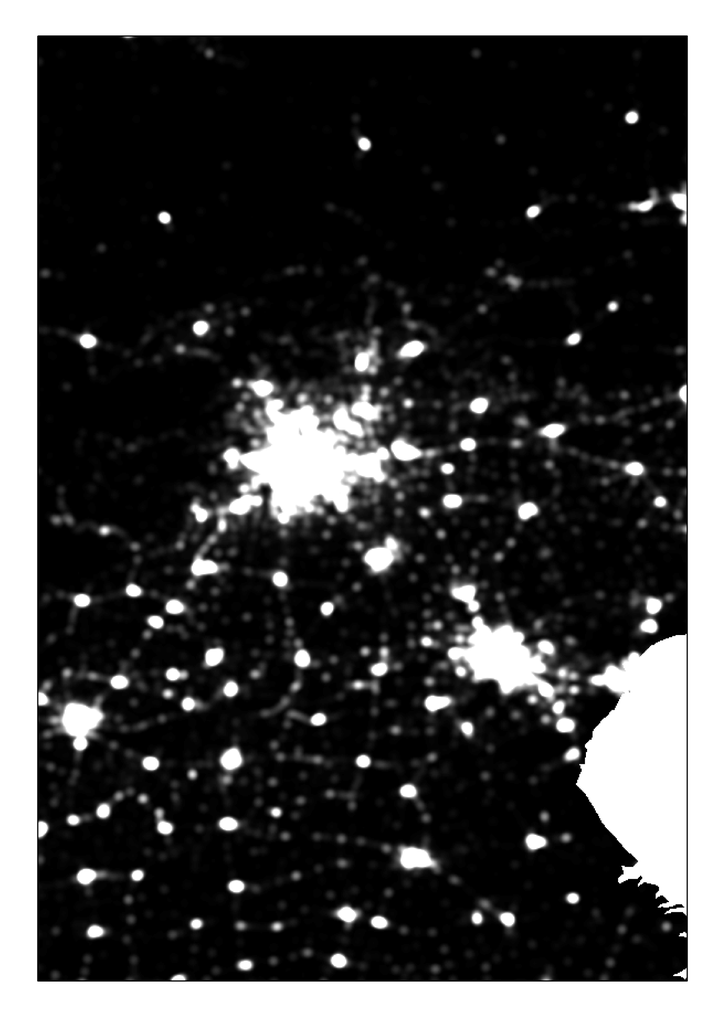

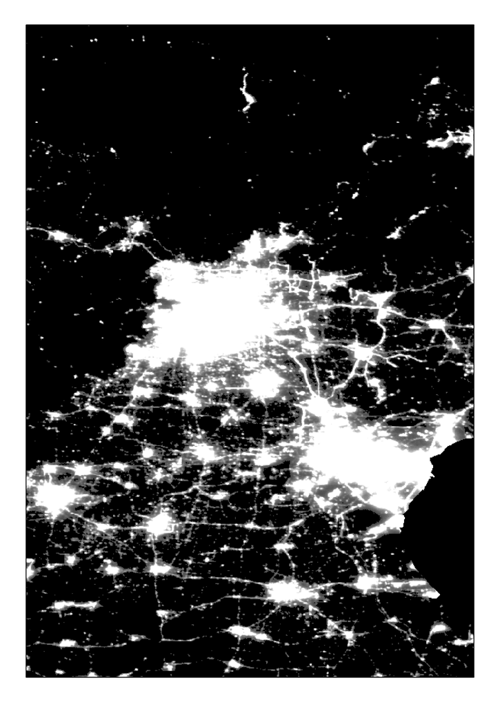

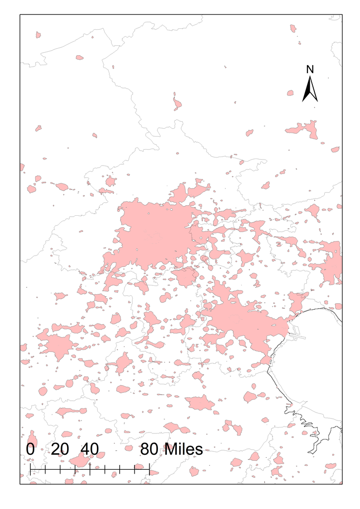

1. KDE of POIs in 2018, b) NTL data for 2018, c) Final Urban extent from composition